# Lab3

# Analizar si se puede hacer agrupamiento por medio de hopkings

```r
set.seed(123)
hopkins(datos_numericos)
```

```
## [1] 1
```

```r
datos_dist <- dist(datos_numericos)
```

Como se puede visualizar al momento de hacer el hopkings del set de datos el valor resultante fue de 1 por lo que se puede mencionar que este esta alejado del 0.5 por lo que se puede proceder a hacer el metodo de agrupamiento

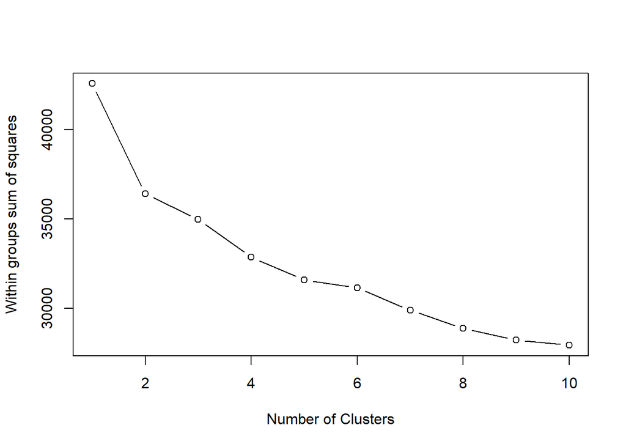

```r
wss=0
for (i in 1:10)
  wss[i] <- sum(kmeans(datos_numericos, centers=i)$withinss)
plot(1:10, wss, type="b", xlab="Number of Clusters",  ylab="Within groups sum of squares")
```

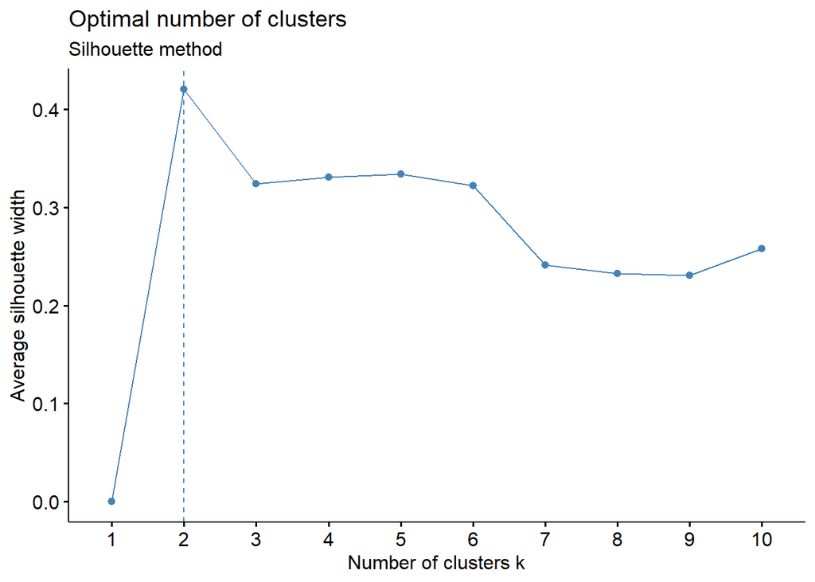

```r
fviz_nbclust(datos_numericos[,1:4], kmeans, method = "silhouette") +
labs(subtitle = "Silhouette method")
```

Se puede visualizar que el numero de Klusters para este set de datos es de 2

## Analisis jerarquico

```r
matriz_dist<- dist(datos_numericos)
```

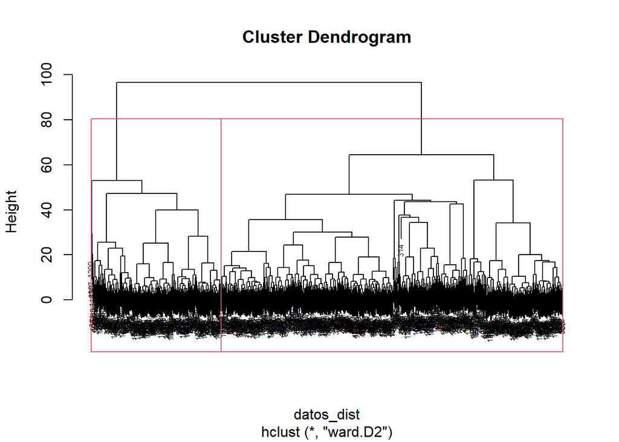

```r
hc <-hclust(datos_dist,method = "ward.D2")
plot(hc, cex=0.5)
rect.hclust(hc,k=2)
```

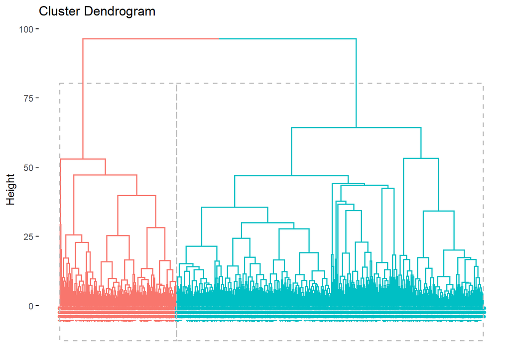

```r
fviz_dend(hc, k=2, rect = T, cex = .5)
```

## Calcular la correlacion de todas las variables con la variable de precio de casas

```r
cor(datos_numericos)
```

```
##                          Id   MSSubClass   LotFrontage      LotArea
## Id             1.0000000000  0.021937479 -0.0132885700 -0.040711142
## MSSubClass     0.0219374785  1.000000000 -0.3869395732 -0.198095532
## LotFrontage   -0.0132885700 -0.386939573  1.0000000000  0.421184102
## LotArea       -0.0407111421 -0.198095532  0.4211841021  1.000000000
## OverallQual   -0.0582692304  0.029521865  0.2413223161  0.167524794
## OverallCond    0.0043866408 -0.087859316 -0.0463116489 -0.034347948
## YearBuilt     -0.0208620907  0.025799678  0.1097255707  0.029205413
## YearRemodAdd  -0.0276643035  0.006645194  0.0864139680  0.026847846
## MasVnrArea    -0.0734716818  0.040239997  0.1899685917  0.106115431
## BsmtFinSF1    -0.0137506789 -0.070388692  0.2413522339  0.230441380
## BsmtFinSF2     0.0125436047 -0.075439002  0.0493053240  0.138233605
## BsmtUnfSF     -0.0129851567 -0.145582343  0.1153058755  0.011288124
## TotalBsmtSF   -0.0231289420 -0.247781211  0.3876195129  0.302553906
## X1stFlrSF     -0.0080455234 -0.252248866  0.4510850287  0.329678689
## X2ndFlrSF     -0.0023457170  0.319327639  0.0750038007  0.074611842
## LowQualFinSF  -0.0399333771  0.024703650  0.0111480855  0.020039426
## GrLivArea     -0.0110683576  0.083365382  0.3963060214  0.307163514
## BsmtFullBath   0.0261125979 -0.014681299  0.1180881480  0.179051563
## BsmtHalfBath  -0.0267735790  0.012309569  0.0004335725 -0.014281611
## FullBath       0.0072200531  0.131278047  0.1857853092  0.129073367
## HalfBath      -0.0104087038  0.203970613  0.0456783485  0.045183485
## BedroomAbvGr   0.0398314240 -0.032971146  0.2704038861  0.137268663
## KitchenAbvGr   0.0259125317  0.266012356 -0.0035464716 -0.018941546
## TotRmsAbvGrd   0.0200115088  0.047209430  0.3484211056  0.237917977
## Fireplaces    -0.0182727886 -0.031122227  0.2603208280  0.255754683
## GarageYrBlt   -0.0020389225  0.054701367  0.0698781184  0.013730760
## GarageCars    -0.0081253594 -0.027410668  0.2865868103  0.172428230
## GarageArea    -0.0258890142 -0.092607262  0.3568509373  0.211362399
## WoodDeckSF    -0.0250599470 -0.017988416  0.0821656268  0.133576037
## OpenPorchSF   -0.0019720177  0.004053970  0.1618151174  0.099170000
## EnclosedPorch  0.0099349300 -0.017789898  0.0142610142 -0.023630663
## X3SsnPorch    -0.0668330801 -0.039738957  0.0697157667  0.012520261
## ScreenPorch    0.0151829080 -0.021789344  0.0359059844  0.072517046
## PoolArea       0.0480096047  0.003166468  0.2117461173  0.109147070
## MiscVal        0.0457990995 -0.040688673  0.0014707377  0.012789992
## MoSold        -0.0005698686 -0.027170383  0.0188145348  0.008998481
## YrSold         0.0134066434 -0.012447829  0.0132670710 -0.006903891
## SalePrice     -0.0471218502 -0.088031702  0.3442697721  0.299962206
##                OverallQual  OverallCond    YearBuilt YearRemodAdd   MasVnrArea
```

[output cut: 296 more lines]

```
## TotRmsAbvGrd   0.0430971157 -2.481218e-02  0.547067360
## Fireplaces     0.0487881198 -3.140227e-02  0.461872689
## GarageYrBlt    0.0092328776  9.596052e-03  0.504753018
## GarageCars     0.0574811549 -3.350744e-02  0.647033611
## GarageArea     0.0375965578 -1.620605e-02  0.619329622
## WoodDeckSF     0.0415471550  1.480997e-02  0.336855121
## OpenPorchSF    0.0897669215 -5.303516e-02  0.343353812
## EnclosedPorch -0.0610833426 -1.184577e-03 -0.154843204
## X3SsnPorch     0.0222600929  2.073068e-02  0.030776594
## ScreenPorch    0.0128592605 -4.118063e-03  0.110426815
## PoolArea      -0.0548723613 -5.388769e-02  0.092488120
## MiscVal        0.0200670615  3.410608e-02 -0.036041237
## MoSold         1.0000000000 -1.505766e-01  0.051568064
## YrSold        -0.1505766122  1.000000e+00 -0.011868823
## SalePrice      0.0515680637 -1.186882e-02  1.000000000
```

Como se puede visualizar en la tabla para el dato de Saleprice existen dos columnas con una relacion mayor a 0.7 las cuales son GrLivArea y OverallQual por lo que procedera a crear un data set con estas variables aisladas